# Markdown

“Ïntroduction of our project” “Within past years chicago has whitnessed a dramatic resurgence of crimes and violence, these conflicts,robberies and tragedies are happening every day around the city, and to tackle this issue i am going to analyze the historical crime data and conducting predictive analysis so we can identify the pattern in the crimes data and informed the police departments so they can allocate police forcies on desired areas and try to prevent tragedies from happening”

“First part will cover the following points Articulate what patterns/relationships you are seeing in the data”

“Now lets start our project before going on the predictive analysis lets first analyze the datasets through visualizations”

```r
library(ggplot2)
library(dplyr)
library(caTools)
library(e1071)
library(MASS)
library(class)

#Read data from the file and save that in the variable
Chicago_data <- read.csv(file="Chicago_Crimes_2012_to_2017.csv", header=TRUE)
Chicago_data <- na.omit(Chicago_data)

#"Lets summarize the data first"
summary(Chicago_data)
```

```
##        X                 ID             Case.Number
##  Min.   :      3   Min.   :   20224   HZ140230:      6
##  1st Qu.:2696734   1st Qu.: 8987142   HZ403466:      4
##  Median :3052459   Median : 9576373   HZ554936:      4
##  Mean   :3273592   Mean   : 9574958   HV217424:      3
##  3rd Qu.:3409868   3rd Qu.:10191992   HW486725:      3
##  Max.   :6253474   Max.   :10823344   HY259141:      3
##                                       (Other) :1419568
##                      Date
##  01/01/2012 12:01:00 AM:    126
##  01/01/2015 12:01:00 AM:     97
##  01/01/2015 12:00:00 AM:     88
##  01/01/2012 12:00:00 AM:     78
##  01/01/2013 09:00:00 AM:     77
##  01/01/2014 12:01:00 AM:     74
##  (Other)               :1419051
##                                  Block              IUCR
##  001XX N STATE ST                   :   3570   0820   :133303
##  0000X W TERMINAL ST                :   2671   0486   :128283
##  008XX N MICHIGAN AVE               :   2432   0460   : 86510
##  076XX S CICERO AVE                 :   2092   0810   : 72957
##  0000X N STATE ST                   :   1811   1320   : 71362
##  064XX S DR MARTIN LUTHER KING JR DR:   1319   1310   : 70342
##  (Other)                            :1405696   (Other):856834
##           Primary.Type                     Description
##  THEFT          :322423   SIMPLE                 :147846
##  BATTERY        :258942   $500 AND UNDER         :133303
##  CRIMINAL DAMAGE:152813   DOMESTIC BATTERY SIMPLE:128283
##  NARCOTICS      :131177   TO VEHICLE             : 74572
##  ASSAULT        : 89508   OVER $500              : 72957
##  OTHER OFFENSE  : 85362   TO PROPERTY            : 70342
##  (Other)        :379366   (Other)                :792288
##                      Location.Description   Arrest         Domestic
##  STREET                        :325084    False:1048530   False:1204457
##  RESIDENCE                     :223854    True : 371061   True : 215134
##  APARTMENT                     :179444
##  SIDEWALK                      :158478
##  OTHER                         : 53474
##  PARKING LOT/GARAGE(NON.RESID.): 40907
##  (Other)                       :438350
```

[output cut: 17 more lines]

```
##  02/04/2016 06:33:39 AM:906829   Min.   :36.62   Min.   :-91.69
##  08/17/2015 03:03:40 PM:152196   1st Qu.:41.77   1st Qu.:-87.72
##  04/15/2016 03:49:27 PM:  7853   Median :41.86   Median :-87.67
##  09/10/2015 11:43:14 AM:  6458   Mean   :41.84   Mean   :-87.67
##  10/09/2015 03:58:54 PM:  6016   3rd Qu.:41.91   3rd Qu.:-87.63
##  08/31/2015 03:43:09 PM:  5056   Max.   :42.02   Max.   :-87.52
##  (Other)               :335183
##                           Location
##  (41.883500187, -87.627876698):   2096
##  (41.754592961, -87.741528537):   2084
##  (41.979006297, -87.906463155):   1338
##  (41.897895128, -87.624096605):   1320
##  (41.742710224, -87.634088181):   1122
##  (41.909664252, -87.742728815):   1076
##  (Other)                      :1410555
```

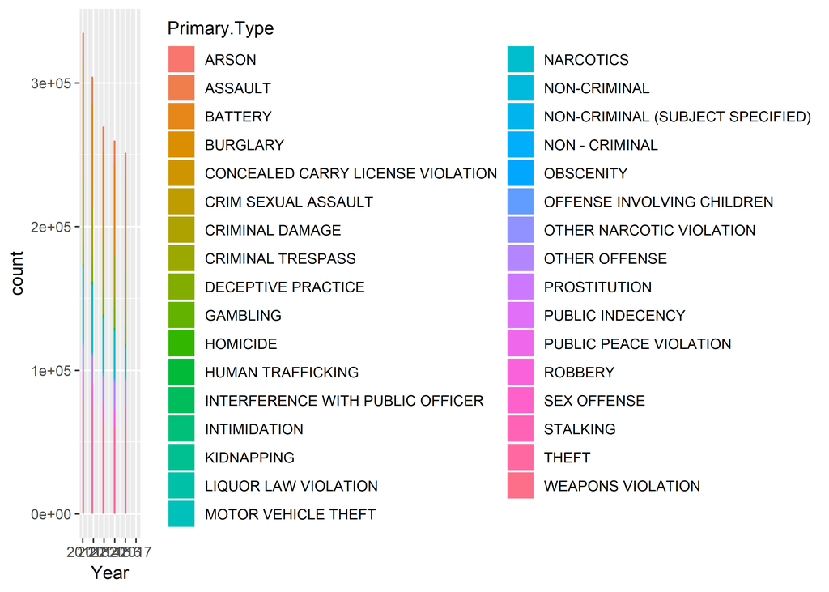

```r
#"We are using dataset from year 2012 to 2017"

#"Now lets move towards the First Part of our Project"
#"Exploratory Data Analysis"

#"Visual No 1"
#"Lets find the Total Number of crimes going down across years"
plot_1 <- ggplot(data=Chicago_data,aes(x=Year, group=Primary.Type, fill=Primary.Type)) +geom_histogram()
plot_1
```

“Here is the first plot of our data and it gives us very clear insights that Theft Type crimes are the main crimes from year 2012 to year 2017” “One more thing we came to know that in 2017 crimes rate reduced drastically as compared to other years moreover 2012 has most crimes”

“Visual No 2”

“Now find the crime rates per month for this we have to change the format of date so that it is being understood by R” “Below are the steps that are used to convert date into a format which is being understood by R”

```r
summary(Chicago_data$Date)
```

[output not shown]

[output cut: 13 more lines]

[output not shown]

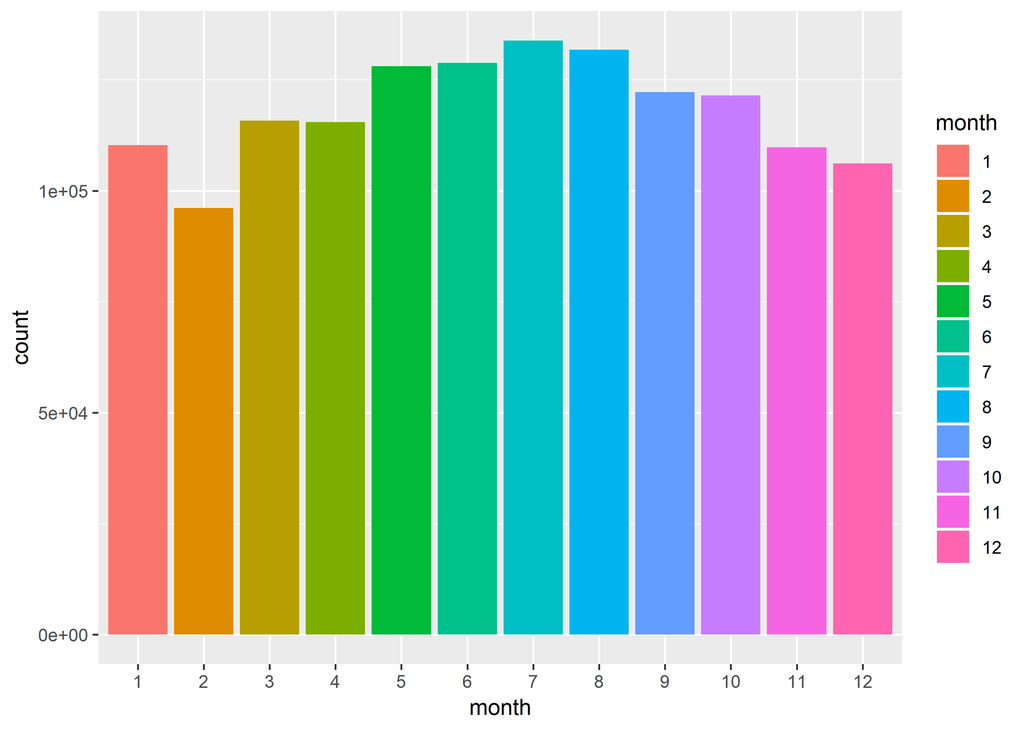

```r
#"This part covers the following point
#Exploratory Data Analysis/Transformation:"
date<- as.POSIXlt(Chicago_data$Date, format = "%m/%d/%Y %I:%M:%S %p")
Chicago_data$Date <- date
Chicago_data$day <- as.factor(Chicago_data$Date$mday)
Chicago_data$hour <- as.factor(Chicago_data$Date$hour)
Chicago_data$month <- as.factor(Chicago_data$Date$mon+1)
Chicago_data$year <- as.factor(Chicago_data$Date$year+1900)
Chicago_data$weekday <- as.factor(Chicago_data$Date$wday+1)

#"Convert the date variable to type Date"
Chicago_data$Date <- as.Date(Chicago_data$Date, format = "%m/%d/%Y %I:%M:%S %p")



#"Now we have seperate columns for months we can visualize the crimes rates with respect to different months"
plot_2 <- ggplot(data=Chicago_data,aes(x=month,fill=month)) +geom_histogram(stat = 'count')
plot_2
```

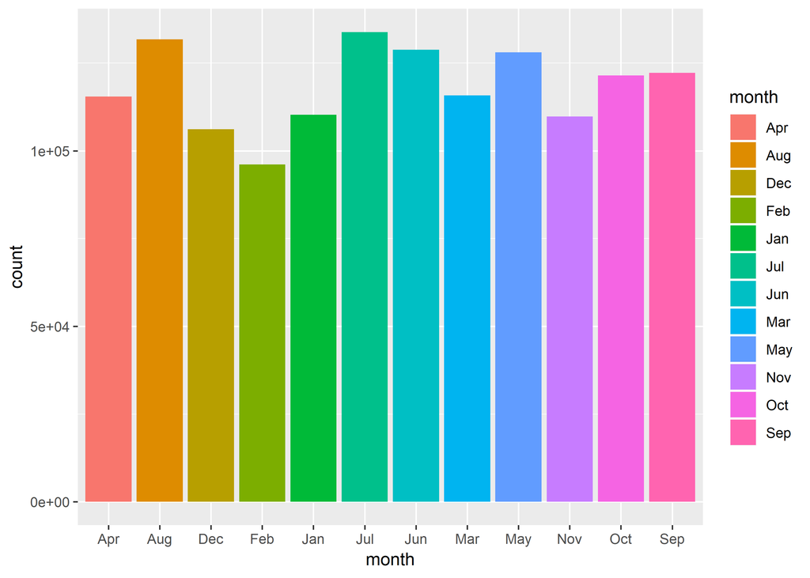

```r
#"Lets change numeric of plot and add month names instead of numbers"
Chicago_data$month <- month.abb[Chicago_data$month]

#"Now again make a plot and see the results"

plot_2 <- ggplot(data=Chicago_data,aes(x=month,fill=month)) +geom_histogram(stat = 'count')
plot_2
```

“From this we can see that Month of July has the most number of crimes as compared to other months”

“Now look at the trends of different crimes types for this we have to filter the orignal data and for that lets make a new data frame”

“As there are many types of crimes we are focusing on the important ones here”

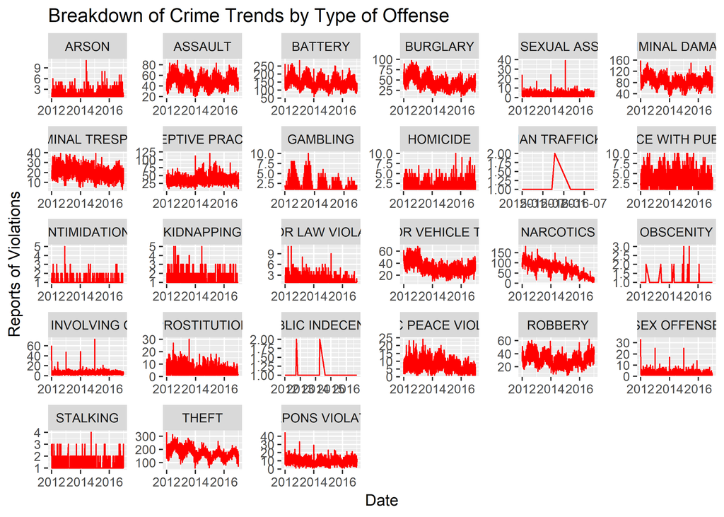

```r
Type_of_crimes <- Chicago_data %>%
  group_by(Primary.Type, Date) %>%
  summarize(total = n()) %>%
  filter(Primary.Type != "CONCEALED CARRY LICENSE VIOLATION",
         Primary.Type!= "NON-CRIMINAL",
         Primary.Type!= "NON-CRIMINAL (SUBJECT SPECIFIED)",
         Primary.Type!= "NON - CRIMINAL",
         Primary.Type!= "OTHER NARCOTIC VIOLATION",
         Primary.Type!= "OTHER OFFENSE")


ggplot(data=Type_of_crimes,aes(x = Date, y = total)) +
  geom_line(color = "red") +
  facet_wrap(~Primary.Type, scales = "free") +
  ggtitle(label = "Breakdown of Crime Trends by Type of Offense") +
  scale_y_continuous(name = "Reports of Violations")
```

“These are the major crimes rates you can see that narcotics crimes are reduced as we compared to other crimes over the years”

“So our analysis are being done and we conclude some important analysis which are explained below” “1) Theft crimes are the most prominent crimes in the chicago over the years and police should trained itselt to tackle with Theft crimes and always be prepared to tackle such an event one, police should install security cameras where Theft crimes are mostly reported or in rushy areas and identify the culprits through this way police will be able to reduce the Theft crimes” “2) July has the most crimes reported so in that month there will be more police and petrolling police in the city Chicago as compared to other months”

“3) Narcotics crime rate has reduced over the years and we should focus on other crimes and give less time to narcotics as compared to other because it’s already controlled”

“Second Part of our project will cover the following points of the requirements 1) Training/test/validation: 2) Modelling”

“Part (i)”

“Lets split the data into two parts First Training Data and second Test Part”

“Our dataset is very big contains about 1.4 million rows and we would require GPU to process that so i am restricting the rows to Tewenty Thousand so we can train our model effeciently”

```r
Model_data <- tail(Chicago_data,n=20000)


#"Here our data is splitted into two parts (Segmentation)
#Training Dataset and Test DataSet"
split = sample.split(Model_data, SplitRatio = 2/3)
train = subset(Model_data, split == TRUE)
test = subset(Model_data, split == TRUE)

#"Our main technique is Supervised Learning"


#"We are applying here KNN model here"

trainKNN = train[,c("Arrest","Beat","District","Ward","Community.Area")]
trainKNN$Arrest = as.logical(trainKNN$Arrest)
testKNN = test[,c("Arrest","Beat","District","Ward","Community.Area")]
testKNN$Arrest = as.logical(testKNN$Arrest)
#Training and testing the model
length(trainKNN)
```

```
## [1] 5
```

```r
length(trainKNN$Arrest)
```

```
## [1] 12857
```

```r
testautoknn = knn(train = trainKNN, cl = trainKNN$Arrest, test = testKNN, k = 3)
trainautoknn = knn(train = trainKNN, cl = trainKNN$Arrest, test = trainKNN, k = 3)
table(testKNN$Arrest,testautoknn)
```

```
##        testautoknn
##         FALSE  TRUE
##   FALSE 10610     4
##   TRUE    243  2000
```

```r
"As we can see from the table it is quite good observation if we compared with True False and True TRUE so this model
outperforms our analysis"
```

```
## [1] "As we can see from the table it is quite good observation if we compared with True False and True TRUE so this model\noutperforms our analysis"
```

```r
"Second model we are using is Linear Regression"
```

```
## [1] "Second model we are using is Linear Regression"
```

```r
summary(lm(as.numeric(Arrest)~Beat+District+Ward+Community.Area,data=train))
```

```
##
## Call:
## lm(formula = as.numeric(Arrest) ~ Beat + District + Ward + Community.Area,
##     data = train)
##
## Residuals:
##     Min      1Q  Median      3Q     Max
## -0.3298 -0.1839 -0.1665 -0.1501  0.8703
##
## Coefficients:
##                  Estimate Std. Error t value Pr(>|t|)
## (Intercept)     1.1218102  0.0155722  72.039  < 2e-16 ***
## Beat            0.0007812  0.0003893   2.007   0.0448 *
## District       -0.0792305  0.0390493  -2.029   0.0425 *
## Ward            0.0007559  0.0003336   2.266   0.0235 *
## Community.Area  0.0008089  0.0001894   4.271 1.96e-05 ***
## ---
## Signif. codes:  0 '***' 0.001 '**' 0.01 '*' 0.05 '.' 0.1 ' ' 1
##
## Residual standard error: 0.3791 on 12852 degrees of freedom
## Multiple R-squared:  0.002306,   Adjusted R-squared:  0.001996
## F-statistic: 7.427 on 4 and 12852 DF,  p-value: 5.701e-06
```

```r
"We look from this model that linear regression model is not a good choice as it shows us very poor results"
```

```
## [1] "We look from this model that linear regression model is not a good choice as it shows us very poor results"
```